# Investigate a Dataset - Titanic

## Questions

1. What's the ratio of the number of female survived to the number of male survived?
2. Did passengers in the first pclass tend to have higher possibility being survived?

## Wrangle

```python
import seaborn as sns
import pandas as pd

titanic_df=pd.read_csv('titanic-data.csv')
```

```python
titanic_visual=pd.DataFrame(titanic_data)
titanic_visual['Survived'].replace({0:'Passengers_Died', 1:'Passengers_Survived'}, inplace=True)
```

*Explore how many uniques passengers in the dataset, how many passengers survived and how many passengers didn't survive*

```python
len(titanic_df['PassengerId'].unique())
```

```
891
```

```python
l=titanic_visual.groupby('Survived').count()['PassengerId']
print(l)
```

```
Survived
Passengers_Died        549
Passengers_Survived    342
Name: PassengerId, dtype: int64
```

```python
%matplotlib inline
import matplotlib.pyplot as plt
```

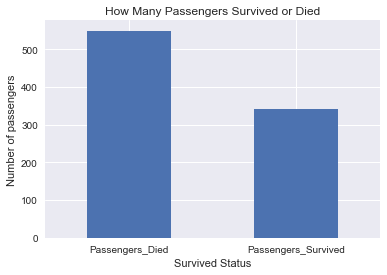

```python
plt.title("How Many Passengers Survived or Died")
l.plot('bar',rot=0)
plt.xlabel("Survived Status")
plt.ylabel('Number of passengers')
```

*It turned out that the number of died passengers is greater than the number of survived passengers. To be specific, there's 549 passengers died, and 342 passengers survived in this sample dataset.*

*Get a look at how data looks like*

```python
print(titanic_data.head())
```

```
   PassengerId             Survived  Pclass  \
0            1      Passengers_Died       3
1            2  Passengers_Survived       1
2            3  Passengers_Survived       3
3            4  Passengers_Survived       1
4            5      Passengers_Died       3

                                                Name     Sex   Age  SibSp  \
0                            Braund, Mr. Owen Harris    male  22.0      1
1  Cumings, Mrs. John Bradley (Florence Briggs Th...  female  38.0      1
2                             Heikkinen, Miss. Laina  female  26.0      0
3       Futrelle, Mrs. Jacques Heath (Lily May Peel)  female  35.0      1
4                           Allen, Mr. William Henry    male  35.0      0

   Parch            Ticket     Fare Cabin Embarked
0      0         A/5 21171   7.2500   NaN        S
1      0          PC 17599  71.2833   C85        C
2      0  STON/O2. 3101282   7.9250   NaN        S
3      0            113803  53.1000  C123        S
4      0            373450   8.0500   NaN        S
```

### **Deal with missing values**

```python
titanic_data.isnull().sum()
```

```
PassengerId      0
Survived         0
Pclass           0
Name             0
Sex              0
Age            177
SibSp            0
Parch            0
Ticket           0
Fare             0
Cabin          687
Embarked         2
dtype: int64
```

*From above results, I know that the dataset is missing 177 "Age" variables, 687 "Cabin" variables, and 2 "Embarked' variables. The "Age" variables is crucial in the analysis. Therefore, when analyzing questions related with "Age" variable, it's better to exclude the data without age values. The following codes will exclude the data missing age values:*

```python
valid_ages = titanic_data.dropna(subset=["Age"])
valid_ages.count()[['Age','Survived']]
```

```
Age         714
Survived    714
dtype: int64
```

```python
valid_ages.isnull().sum()[['Age','Survived']]
```

```
Age         0
Survived    0
dtype: int64
```

*When analyzing questions related to "Age" variable, it's better to use "valid_ages" dataframe. According to my listed questions, I will not analyze "Age" related questions. So it's better not to exclude these data.*

*Considering my questions, I think I should split data into two groups: passengers who survived and who didn't survive:*

```python
grouped_passengers=titanic_df.groupby('Survived').groups
print(grouped_passengers)
```

```
{0: Int64Index([  0,   4,   5,   6,   7,  12,  13,  14,  16,  18,
            ...
            877, 878, 881, 882, 883, 884, 885, 886, 888, 890],
           dtype='int64', length=549), 1: Int64Index([  1,   2,   3,   8,   9,  10,  11,  15,  17,  19,
            ...
            865, 866, 869, 871, 874, 875, 879, 880, 887, 889],
           dtype='int64', length=342)}
```

## Explore

### **Question 1: What's the ratio of the number of survived female to the number of survived male?**

*First I grouped dataframe by "Sex" and "Survived" variables using following codes:*

```python
titanic_visual.groupby(['Sex','Survived'])
```

```
<pandas.core.groupby.DataFrameGroupBy object at 0x1154392b0>
```

```python
male_survived_df=titanic_visual.groupby(['Sex','Survived']).get_group(('male','Passengers_Survived'))
female_survived_df=titanic_visual.groupby(['Sex','Survived']).get_group(('female','Passengers_Survived'))
```

*I calculated the number of survived female passengers and male passengers. Then I divided the number of survived female passengers by the number of survived male passengers to calculate the ratio.**

```python
num_female_survived=female_survived_df['Survived'].count()
num_male_survived=male_survived_df['Survived'].count()
ratio_survived_sex=num_female_survived / num_male_survived

print(ratio_survived_sex)
```

```
2.1376146789
```

**Ratio of Survived Females Passengers to Survived Male Passengers :**

```python
from fractions import Fraction

Fraction(ratio_survived_sex).limit_denominator()
```

```
Fraction(233, 109)
```

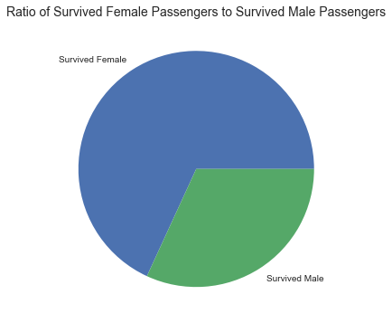

```python
import numpy as np
data = [233, 109]
plt.figure(num=1, figsize=(6, 6))
plt.axes(aspect=1)
plt.title('Ratio of Survived Female Passengers to Survived Male Passengers', size=14)
plt.pie(data, labels=('Survived Female', 'Survived Male'))
```

*From this pie chart, it's earsier to see the part representing the number of survived female is bigger than the part representing the number of survived male. According to above result, the ratio of the number of survived female passenger to the number of survived male passengers is 233 to 109.*

**Number of Survived Female and Survived Male Passengers**

```python
print(num_female_survived,num_male_survived)
```

```
233 109
```

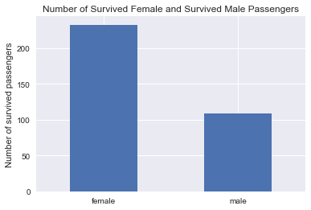

```python
import pandas as pd

num_survived=pd.Series((num_female_survived,num_male_survived),index=['female','male'])


plt.title('Number of Survived Female and Survived Male Passengers')
num_survived.plot('bar',rot=0)

plt.ylabel("Number of survived passengers")
```

### **Question 2: Did passengers in the first pclass tend to have higher possibility being survived?**

### Frequency test

*I want to calculated the percentages of survived passengers in each pclass. So first, I grouped data by "Pclass" and "Survived" variables:*

```python
titanic_df.groupby(['Pclass','Survived'])
```

```
<pandas.core.groupby.DataFrameGroupBy object at 0x115444ac8>
```

*For convenience, I replaced the "Survived" variables' values back to "0" and "1":*

```python
titanic_visual['Survived'].replace({'Passengers_Died':0, 'Passengers_Survived':1}, inplace=True)
```

*Second, I counted survived passengers in the first pclass and in other pclasses by suming "Survived" variables in the grouped data. Then, divided by the number of passengers in that pclass:*

```python
pclass1_survived=titanic_df.groupby(['Pclass']).get_group(1).sum()['Survived']
pclass1_passengers=titanic_df.groupby(['Pclass']).get_group(1).count()['Survived']

p1=pclass1_survived / pclass1_passengers
print(p1)
```

```
0.62962962963
```

```python
pclass2_survived=titanic_df.groupby(['Pclass']).get_group(2).sum()['Survived']
pclass2_passengers=titanic_df.groupby(['Pclass']).get_group(2).count()['Survived']

p2=pclass2_survived / pclass2_passengers
print(p2)
```

```
0.472826086957
```

```python
pclass3_survived=titanic_df.groupby(['Pclass']).get_group(3).sum()['Survived']
pclass3_passengers=titanic_df.groupby(['Pclass']).get_group(3).count()['Survived']

p3=pclass3_survived / pclass3_passengers
print(p3)
```

```
0.242362525458
```

```python
p_others=(pclass2_survived+pclass3_survived)/(pclass3_passengers+pclass3_passengers)
```

**Percentages of Survived Passengers in the First Pclass and in Other Pclasses**

```python
print(' first class', ' ','other classes')
print(p1,p_others)
```

```
 first class   other classes
0.62962962963 0.209775967413
```

*The following bar chart would bring a clearer result:*

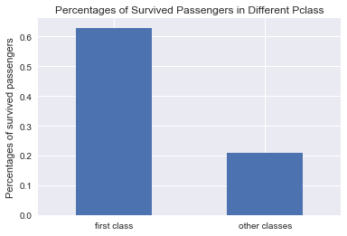

```python
b=pd.Series([p1,p_others],index=['first class','other classes'])

b.plot('bar',rot=0,title="Percentages of Survived Passengers in Different Pclass")
plt.ylabel("Percentages of survived passengers")
```

### Chi-square test

*Now I want to add statistical test to further support my above finding. My null hypothesis is that the possibility being survived are equal between the first pclass and other pclasses.*

*According to the null hypothesis, the expected number of survived passengers for each pclass should be the overall survival rate times passenger number in each pclass:*

```python
#expected group:#
expected_rate=titanic_df['Survived'].mean()
titanic_df.groupby(['Pclass']).count()
```

| Pclass | PassengerId | Survived | Name | Sex | Age | SibSp | Parch | Ticket | Fare | Cabin | Embarked |
| --- | --- | --- | --- | --- | --- | --- | --- | --- | --- | --- | --- |
| 1 | 216 | 216 | 216 | 216 | 186 | 216 | 216 | 216 | 216 | 176 | 214 |
| 2 | 184 | 184 | 184 | 184 | 173 | 184 | 184 | 184 | 184 | 16 | 184 |
| 3 | 491 | 491 | 491 | 491 | 355 | 491 | 491 | 491 | 491 | 12 | 491 |

```python
#expected group:#
p1_expected_survived=titanic_df.groupby(['Pclass']).get_group(1).count()['PassengerId']*expected_rate
p2_expected_survived=titanic_df.groupby(['Pclass']).get_group(2).count()['PassengerId']*expected_rate
p3_expected_survived=titanic_df.groupby(['Pclass']).get_group(3).count()['PassengerId']*expected_rate
```

*The observed outcomes are from the actual number of survived passengers in each pclass:*

```python
#observed group:#
titanic_df.groupby(['Pclass']).sum()
```

| Pclass | PassengerId | Survived | Age | SibSp | Parch | Fare |
| --- | --- | --- | --- | --- | --- | --- |
| 1 | 99705 | 136 | 7111.42 | 90 | 77 | 18177.4125 |
| 2 | 82056 | 87 | 5168.83 | 74 | 70 | 3801.8417 |
| 3 | 215625 | 119 | 8924.92 | 302 | 193 | 6714.6951 |

```python
#observed group:#
p1_survived=titanic_df.groupby(['Pclass']).get_group(1).sum()['Survived']
p2_survived=titanic_df.groupby(['Pclass']).get_group(2).sum()['Survived']
p3_survived=titanic_df.groupby(['Pclass']).get_group(3).sum()['Survived']
```

*I'm focusing on passengers in the first pclass and in other pclasses, so I combined passengers number in the second and third pclass:*

```python
pothers_survived=p2_survived+p3_survived
pothers_expected_survived=p2_expected_survived+p3_expected_survived
```

*Calculating p-value using chi_square:*

```python
from scipy.stats import chisquare
chisquare([p1_survived,pothers_survived],f_exp=[p1_expected_survived,pothers_expected_survived])
```

```
Power_divergenceResult(statistic=44.875789473684208, pvalue=2.0993758249200262e-11)
```

*From the pvalue( which is way more smaller than 0.05), we can reject the null hypothesis. According to this test and the previous frequency test, I found out that passengers in the first pclass tend to have a higher possibility being survived.*

## Draw Conclusions

### **Tentative conclusion:**

Firstly, according to my first question, through my computation, pie charts and bar chart, I found that the number of survived female passengers is way more than the number of survived male passengers. The ratio of these two numbers is 233:109.

Secondly, I analyzed the 'pclass'and the 'survived' variables, using both frequency test and statitical test(chi_square test). The reason why I think passengers in the first pclasses might have different rates of survival is that wealthy people might be put on lifeboats first. Or maybe it's because of where their cabins were on the boat. It turned out that passengers in the first pclass actually tend to have a higher possibility being survived.

Although, there's might be some limitations of the data. Because we don't know how representative this sample is. It's better to make sure the sample we analyzed is representative enough to make such conclusions.

## **Reference:**

https://discussions.udacity.com/t/removing-missing-values/299283/2

https://stackoverflow.com/questions/32244019/how-to-rotate-x-axis-tick-labels-in-pandas-barplot

https://matplotlib.org/examples/pie_and_polar_charts/pie_demo_features.html

https://stackoverflow.com/questions/20124472/python-float-to-ratio

http://www.th7.cn/Program/Python/201412/325891.shtml

https://discussions.udacity.com/t/chi-square-test-of-independence-survivability-and-class/244662/7

https://discussions.udacity.com/t/dataset-limitation-review/241549/2